# Ex. 04-2: Downstream ATAC-seq analysis

## 1. Import ATAC peaks from YAPC

YAPC has mapped peaks with several different thresholds of significance.

> Check how many peaks were mapped at each threshold.

```bash
wc -l Share/day04/_yapc-files/stress-response_*.bed
```

```
##     4419 Share/day04/_yapc-files/stress-response_0.001.bed
##     5056 Share/day04/_yapc-files/stress-response_0.005.bed
##     5384 Share/day04/_yapc-files/stress-response_0.01.bed
##     6514 Share/day04/_yapc-files/stress-response_0.05.bed
##     7439 Share/day04/_yapc-files/stress-response_0.1.bed
##     9321 Share/day04/_yapc-files/stress-response_0.2.bed
##    25032 Share/day04/_yapc-files/stress-response_peaksall.bed
##    63165 total
```

> Which type of genomic locus does an ATAC peak corresponds to? A priori, which YAPC significance threshold seems to yield the most appropriate number of peaks?

```r
# Import ATAC peaks as GRanges
library(tidyverse)
ATAC_peaks <- read.table('Share/day04/_yapc-files/stress-response_0.05.bed') %>%
    as_tibble() %>%
    setNames(c('seqnames', 'start', 'end', 'yapc_scores', 'score', 'strand', 'summit', 'summit2')) %>%
    GenomicRanges::makeGRangesFromDataFrame(keep.extra.columns = TRUE)
ATAC_peaks$peakID <- paste0('peak_', 1:length(ATAC_peaks))
ATAC_peaks$yapc_scores <- NULL
ATAC_peaks$summit2 <- NULL
ATAC_peaks$score <- NULL
ATAC_peaks
```

```
## GRanges object with 6513 ranges and 2 metadata columns:
##          seqnames        ranges strand |    summit      peakID
##             <Rle>     <IRanges>  <Rle> | <integer> <character>
##      [1]        I        78-552      * |        78      peak_1
##      [2]        I     1193-1481      * |      1193      peak_2
##      [3]        I     2415-2738      * |      2415      peak_3
##      [4]        I     6342-6539      * |      6342      peak_4
##      [5]        I     9304-9545      * |      9304      peak_5
##      ...      ...           ...    ... .       ...         ...
##   [6509]      XVI 941520-941693      * |    941520   peak_6509
##   [6510]      XVI 942541-942742      * |    942541   peak_6510
##   [6511]      XVI 943128-943286      * |    943128   peak_6511
##   [6512]      XVI 944265-944521      * |    944265   peak_6512
##   [6513]      XVI 946186-946398      * |    946186   peak_6513
##   -------
##   seqinfo: 16 sequences from an unspecified genome; no seqlengths
```

## 2. Brief QC of ATAC peaks

> How far from a TSS each peak is?

```r
# Get Yeast TSS annotations from TxDb
yeast_genes <- GenomicFeatures::genes(TxDb.Scerevisiae.UCSC.sacCer3.sgdGene::TxDb.Scerevisiae.UCSC.sacCer3.sgdGene)
GenomeInfoDb::seqlevelsStyle(yeast_genes) <- GenomeInfoDb::seqlevelsStyle(ATAC_peaks)
yeast_TSSs <- GenomicRanges::resize(yeast_genes, 1, 'start')
# Convert Ensembl gene ID to human-readable gene names, using gprofiler2
yeast_IDs <- gprofiler2::gconvert(query = yeast_TSSs$gene_id, organism = 'scerevisiae')
head(yeast_IDs)
```

```
## # A tibble: 6 x 7
##   input_number input target_number target name   description          namespace
##          <int> <chr> <chr>         <chr>  <chr>  <chr>                <chr>
## 1            1 Q0010 1.1           Q0010  Q0010  Dubious open readin… ENSG,ENSP…
## 2            2 Q0032 2.1           Q0032  Q0032  Dubious open readin… ENSG,ENSP…
## 3            3 Q0055 3.1           Q0055  AI2    Reverse transcripta… ENSG,ENSP
## 4            4 Q0075 4.1           Q0075  AI5_B… Protein of unknown … ENSG,ENSP
## 5            5 Q0080 5.1           Q0080  ATP8   Subunit 8 of the F0… ENSG,ENSP
## 6            6 Q0085 6.1           Q0085  ATP6   Subunit a of the F0… ENSG,ENSP
```

```r
yeast_TSSs$gene_name <- yeast_IDs$name[match(yeast_TSSs$gene_id, yeast_IDs$input)]
# Annotate closest TSS for each ATAC peak
ATAC_peaks$associated_gene <- yeast_TSSs$gene_name[nearest(ATAC_peaks, yeast_TSSs, ignore.strand = TRUE)]
# Calculate distance to the nearest TSS for each ATAC peak
dists <- IRanges::distanceToNearest(ATAC_peaks, yeast_TSSs, ignore.strand = TRUE)
summary(mcols(dists)$distance)
```

```
##    Min. 1st Qu.  Median    Mean 3rd Qu.    Max.
##     0.0    17.0   120.0   321.6   397.0  6147.0
```

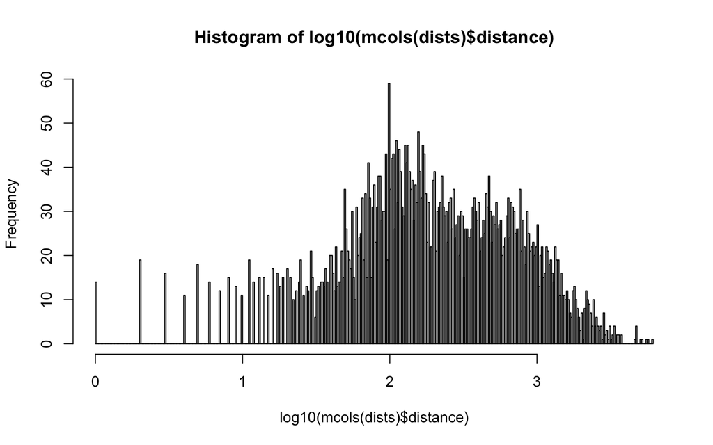

```r
hist(log10(mcols(dists)$distance), breaks = 300)
```

> Compare location of ATAC-seq peaks with that of ChIP-seq peaks

```r
ChIP_peaks <- GenomicRanges::reduce(do.call(c, lapply(
    list.files(pattern = '.*narrowPeak$', path = 'Share/day03/results/bwa/mergedLibrary/macs/narrowPeak', full.names = TRUE), rtracklayer::import
)))
dists <- IRanges::distanceToNearest(ATAC_peaks, ChIP_peaks)
summary(mcols(dists)$distance)
```

```
##    Min. 1st Qu.  Median    Mean 3rd Qu.    Max.
##       0       0       0     120       0   21182
```

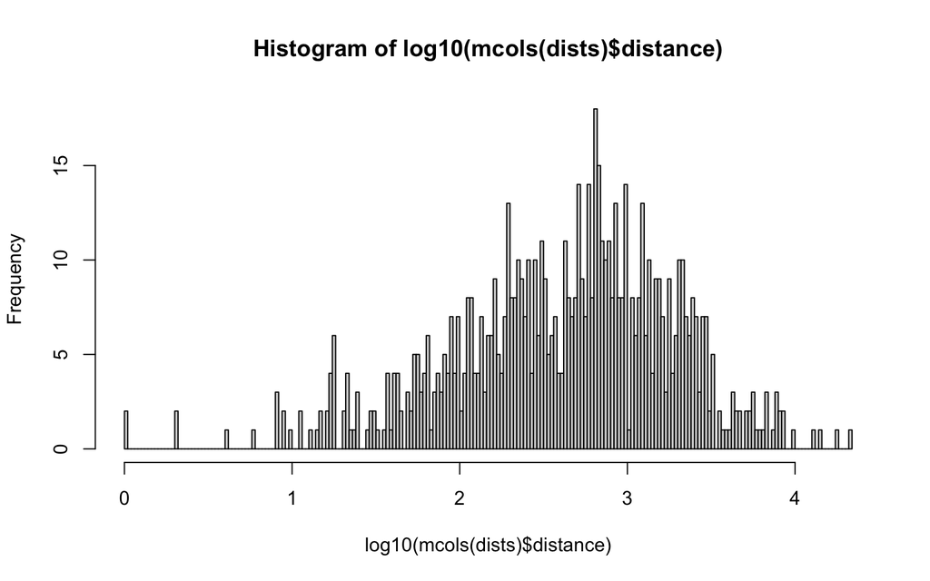

```r
hist(log10(mcols(dists)$distance), breaks = 300)
```

## 3. Count ATAC fragments over ATAC peaks

In R, we can leverage Bioconductor classes and their optimized access to `.bam` files to efficiently count fragment coverage of ATAC-seq datasets over all the annotated ATAC-seq peaks.

```r
# Define sample sheet
sampleTable <- data.frame(
    sample = gsub('_SRR.*', '', list.files(pattern = '_noChrM_q10.bam$', path = 'Share/day04/_bam-files/')),
    timepoint = gsub('SacCer3_|_rep.*', '', list.files(pattern = '_noChrM_q10.bam$', path = 'Share/day04/_bam-files/')),
    replicate = rep(c(1, 2), 5),
    bam = list.files(pattern = '_noChrM_q10.bam$', path = 'Share/day04/_bam-files/', full.names = TRUE)
)
```

```r
# Import fragment counts over peaks
ATAC_counts <- GenomicAlignments::summarizeOverlaps(,
    features = ATAC_peaks,
    reads = Rsamtools::BamFileList(sampleTable$bam),
    ignore.strand = TRUE,
    singleEnd = FALSE
)
SummarizedExperiment::colData(ATAC_counts) <- DataFrame(sampleTable)
```

```r
ATAC_counts
```

```
## class: RangedSummarizedExperiment
## dim: 6513 10
## metadata(0):
## assays(1): counts
## rownames: NULL
## rowData names(3): summit peakID associated_gene
## colnames: NULL
## colData names(4): sample timepoint replicate bam
```

```r
length(ATAC_counts)
```

```
## [1] 6513
```

```r
dim(ATAC_counts)
```

```
## [1] 6513   10
```

```r
dplyr::glimpse(ATAC_counts)
```

```
## Formal class 'RangedSummarizedExperiment' [package "SummarizedExperiment"] with 6 slots
##   ..@ rowRanges      :Formal class 'GRanges' [package "GenomicRanges"] with 7 slots
##   ..@ colData        :Formal class 'DFrame' [package "S4Vectors"] with 6 slots
##   ..@ assays         :Formal class 'SimpleAssays' [package "SummarizedExperiment"] with 1 slot
##   ..@ NAMES          : NULL
##   ..@ elementMetadata:Formal class 'DFrame' [package "S4Vectors"] with 6 slots
##   ..@ metadata       : list()
```

```r
SummarizedExperiment::rowRanges(ATAC_counts)
```

```
## GRanges object with 6513 ranges and 3 metadata columns:
##          seqnames        ranges strand |    summit      peakID associated_gene
##             <Rle>     <IRanges>  <Rle> | <integer> <character>     <character>
##      [1]        I        78-552      * |        78      peak_1         YAL069W
##      [2]        I     1193-1481      * |      1193      peak_2            PAU8
##      [3]        I     2415-2738      * |      2415      peak_3       YAL067W-A
##      [4]        I     6342-6539      * |      6342      peak_4            SEO1
##      [5]        I     9304-9545      * |      9304      peak_5            SEO1
##      ...      ...           ...    ... .       ...         ...             ...
##   [6509]      XVI 941520-941693      * |    941520   peak_6509         YPR202W
##   [6510]      XVI 942541-942742      * |    942541   peak_6510         YPR202W
##   [6511]      XVI 943128-943286      * |    943128   peak_6511         YPR202W
##   [6512]      XVI 944265-944521      * |    944265   peak_6512         YPR204W
##   [6513]      XVI 946186-946398      * |    946186   peak_6513       YPR204C-A
##   -------
##   seqinfo: 16 sequences from an unspecified genome; no seqlengths
```

```r
SummarizedExperiment::colData(ATAC_counts)
```

```
## DataFrame with 10 rows and 4 columns
##             sample   timepoint replicate                    bam
##        <character> <character> <numeric>            <character>
## 1  SacCer3_00_rep1          00         1 Share/day04/_bam-fil..
## 2  SacCer3_00_rep2          00         2 Share/day04/_bam-fil..
## 3  SacCer3_15_rep1          15         1 Share/day04/_bam-fil..
## 4  SacCer3_15_rep2          15         2 Share/day04/_bam-fil..
## 5  SacCer3_30_rep1          30         1 Share/day04/_bam-fil..
## 6  SacCer3_30_rep2          30         2 Share/day04/_bam-fil..
## 7  SacCer3_45_rep1          45         1 Share/day04/_bam-fil..
## 8  SacCer3_45_rep2          45         2 Share/day04/_bam-fil..
## 9  SacCer3_60_rep1          60         1 Share/day04/_bam-fil..
## 10 SacCer3_60_rep2          60         2 Share/day04/_bam-fil..
```

## 4. Perform DA analysis

DESeq2 is probably the most widely used package to compute differential coverage (expression) of chromatin loci (genes). Using raw unnormalized counts, it performs the following steps:

- It estimates the size factors for each library
- It estimates the count-dependant dispersion
- It fits a negative binomial generalized linear model to internally normalized counts
- Finally, it tests for differential coverage of genomic features (e.g. genes or peaks) and estimates the log2 fold-change between different conditions.

```r
library(DESeq2)
# Perform DE analysis
dds <- DESeqDataSet(ATAC_counts, design = ~ timepoint)
dds <- DESeq(dds)
# Prepare contrasts for timepoint pairwise comparison
timepoints <- c('00', '15', '30', '45', '60')
contrasts <- apply(combn(5, 2), 2, function(idx) {
    c('timepoint', timepoints[idx[2]], timepoints[idx[1]])
})
colnames(contrasts) <- apply(contrasts, 2, function(col) paste0(col[2], '_v_', col[3]))
contrasts
# Extract differential accessibility results
out.l2fc <- data.frame(matrix(nrow = nrow(dds), ncol = ncol(contrasts)))
colnames(out.l2fc) <- paste0('L2FC_', colnames(contrasts))
out.padj <- data.frame(matrix(nrow = nrow(dds), ncol = ncol(contrasts)))
colnames(out.padj) <- paste0('padj_', colnames(contrasts))
for (i in 1:ncol(contrasts)) {
    ddr <- results(dds, contrast = contrasts[,i])
    metadata(ddr)$alpha <- 0.01
    out <- as.data.frame(ddr)
    out.l2fc[,i] <- out[, 'log2FoldChange']
    out.padj[,i] <- out[, 'padj']
}
# Get regularized log-normalized accessibility counts
rlogs <- rlog(dds, blind = FALSE)
rlogs
rlogs <- assay(rlogs)
glimpse(rlogs)
colnames(rlogs) <- paste0(sampleTable$timepoint, "_rep", sampleTable$replicate)
rlogs <- matrix(unlist(lapply(
    unique(sampleTable$timepoint),
    function(x) {
        x <- rowMeans(matrix(rlogs[,grep(x, colnames(rlogs))], nrow = nrow(rlogs)))
    }
)), nrow = nrow(rlogs))
rownames(rlogs) <- paste0('peak_', 1:nrow(rlogs))
colnames(rlogs) <- paste0('rlog_', unique(sampleTable$timepoint))
# Collate all results together
results <- cbind(rlogs, out.l2fc, out.padj)
mcols(ATAC_peaks) <- cbind(mcols(ATAC_peaks), results)
```

[output not shown]

```r
ATAC_peaks
```

```
## GRanges object with 6513 ranges and 28 metadata columns:
##          seqnames        ranges strand |    summit      peakID associated_gene
##             <Rle>     <IRanges>  <Rle> | <integer> <character>     <character>
##      [1]        I        78-552      * |        78      peak_1         YAL069W
##      [2]        I     1193-1481      * |      1193      peak_2            PAU8
##      [3]        I     2415-2738      * |      2415      peak_3       YAL067W-A
##      [4]        I     6342-6539      * |      6342      peak_4            SEO1
##      [5]        I     9304-9545      * |      9304      peak_5            SEO1
##      ...      ...           ...    ... .       ...         ...             ...
##   [6509]      XVI 941520-941693      * |    941520   peak_6509         YPR202W
##   [6510]      XVI 942541-942742      * |    942541   peak_6510         YPR202W
##   [6511]      XVI 943128-943286      * |    943128   peak_6511         YPR202W
##   [6512]      XVI 944265-944521      * |    944265   peak_6512         YPR204W
##   [6513]      XVI 946186-946398      * |    946186   peak_6513       YPR204C-A
##            rlog_00   rlog_15   rlog_30   rlog_45   rlog_60 L2FC_15_v_00
```

[output cut: 66 more lines]

```r
glimpse(ATAC_peaks)
```

```
## Formal class 'GRanges' [package "GenomicRanges"] with 7 slots
##   ..@ seqnames       :Formal class 'Rle' [package "S4Vectors"] with 4 slots
##   ..@ ranges         :Formal class 'IRanges' [package "IRanges"] with 6 slots
##   ..@ strand         :Formal class 'Rle' [package "S4Vectors"] with 4 slots
##   ..@ seqinfo        :Formal class 'Seqinfo' [package "GenomeInfoDb"] with 4 slots
##   ..@ elementMetadata:Formal class 'DFrame' [package "S4Vectors"] with 6 slots
##   ..@ elementType    : chr "ANY"
##   ..@ metadata       : list()
```

```r
glimpse(ATAC_peaks@elementMetadata)
```

```
## Formal class 'DFrame' [package "S4Vectors"] with 6 slots
##   ..@ rownames       : NULL
##   ..@ nrows          : int 6513
##   ..@ listData       :List of 28
##   .. ..$ summit         : int [1:6513] 78 1193 2415 6342 9304 11097 14720 17761 20701 25315 ...
##   .. ..$ peakID         : chr [1:6513] "peak_1" "peak_2" "peak_3" "peak_4" ...
##   .. ..$ associated_gene: chr [1:6513] "YAL069W" "PAU8" "YAL067W-A" "SEO1" ...
##   .. ..$ rlog_00        : num [1:6513] 11.18 6.91 7.17 7.96 6.26 ...
##   .. ..$ rlog_15        : num [1:6513] 10.44 6.73 7.15 7.55 5.98 ...
##   .. ..$ rlog_30        : num [1:6513] 10.55 6.47 6.77 7.32 5.83 ...
##   .. ..$ rlog_45        : num [1:6513] 10.55 6.71 7.08 7.56 5.98 ...
##   .. ..$ rlog_60        : num [1:6513] 10.34 6.66 7.01 7.75 6.13 ...
##   .. ..$ L2FC_15_v_00   : num [1:6513] -1.0623 -0.3508 -0.0588 -0.6834 -0.6281 ...
##   .. ..$ L2FC_30_v_00   : num [1:6513] -0.9 -0.876 -0.753 -1.094 -1.001 ...
##   .. ..$ L2FC_45_v_00   : num [1:6513] -0.903 -0.345 -0.119 -0.68 -0.615 ...
##   .. ..$ L2FC_60_v_00   : num [1:6513] -1.173 -0.475 -0.297 -0.34 -0.287 ...
##   .. ..$ L2FC_30_v_15   : num [1:6513] 0.162 -0.526 -0.695 -0.411 -0.373 ...
##   .. ..$ L2FC_45_v_15   : num [1:6513] 0.15941 0.00614 -0.06028 0.00362 0.013 ...
##   .. ..$ L2FC_60_v_15   : num [1:6513] -0.111 -0.124 -0.239 0.344 0.341 ...
##   .. ..$ L2FC_45_v_30   : num [1:6513] -0.00278 0.53175 0.63442 0.41427 0.38599 ...
##   .. ..$ L2FC_60_v_30   : num [1:6513] -0.273 0.401 0.456 0.754 0.714 ...
##   .. ..$ L2FC_60_v_45   : num [1:6513] -0.27 -0.131 -0.178 0.34 0.328 ...
##   .. ..$ padj_15_v_00   : num [1:6513] 0.000095 0.506491 0.932032 0.024343 0.212877 ...
##   .. ..$ padj_30_v_00   : num [1:6513] 0.002809 0.066589 0.133487 0.000141 0.04657 ...
##   .. ..$ padj_45_v_00   : num [1:6513] 0.00471 0.6367 0.90203 0.0582 0.3399 ...
##   .. ..$ padj_60_v_00   : num [1:6513] 2.52e-05 3.47e-01 5.95e-01 3.50e-01 6.38e-01 ...
##   .. ..$ padj_30_v_15   : num [1:6513] 0.87 0.572 0.356 0.536 0.77 ...
##   .. ..$ padj_45_v_15   : num [1:6513] 0.98 1 0.999 1 1 ...
##   .. ..$ padj_60_v_15   : num [1:6513] 0.914 0.928 0.853 0.591 0.779 ...
##   .. ..$ padj_45_v_30   : num [1:6513] 0.999 0.999 0.999 0.999 0.999 ...
##   .. ..$ padj_60_v_30   : num [1:6513] 0.729 0.708 0.654 0.108 0.452 ...
##   .. ..$ padj_60_v_45   : num [1:6513] 0.282 NA NA NA NA ...
##   ..@ elementType    : chr "ANY"
##   ..@ elementMetadata: NULL
##   ..@ metadata       : list()
```

## 5. Check peaks DA between 2 timepoints

```r
# Get peaks whose accessibility increases between 0 and 15 min
g <- ATAC_peaks[which(ATAC_peaks$L2FC_15_v_00 > log2(1.5) & ATAC_peaks$padj_15_v_00 < 0.01)]
g[, 1:2]
```

```
## GRanges object with 217 ranges and 2 metadata columns:
##         seqnames        ranges strand |    summit      peakID
##            <Rle>     <IRanges>  <Rle> | <integer> <character>
##     [1]        I   68715-68903      * |     68715     peak_36
##     [2]        I   82013-82238      * |     82013     peak_46
##     [3]        I 139539-139847      * |    139539     peak_73
##     [4]        I 140084-140222      * |    140084     peak_74
##     [5]       II   79640-79895      * |     79640    peak_155
##     ...      ...           ...    ... .       ...         ...
##   [213]      XVI 525648-525816      * |    525648   peak_6286
##   [214]      XVI 550050-550325      * |    550050   peak_6293
##   [215]      XVI 551781-552084      * |    551781   peak_6294
##   [216]      XVI 645971-646254      * |    645971   peak_6343
##   [217]      XVI 646498-646734      * |    646498   peak_6344
##   -------
##   seqinfo: 16 sequences from an unspecified genome; no seqlengths
```

```r
# Get peaks whose accessibility increases between 0 and 60 min
g <- ATAC_peaks[which(ATAC_peaks$L2FC_60_v_00 > log2(1.5) & ATAC_peaks$padj_60_v_00 < 0.01)]
g[, 1:2]
```

```
## GRanges object with 84 ranges and 2 metadata columns:
##        seqnames        ranges strand |    summit      peakID
##           <Rle>     <IRanges>  <Rle> | <integer> <character>
##    [1]        I   73475-73828      * |     73475     peak_41
##    [2]        I 189477-189624      * |    189477    peak_102
##    [3]       II   79640-79895      * |     79640    peak_155
##    [4]       II 395250-395601      * |    395250    peak_327
##    [5]       II 419627-419960      * |    419627    peak_340
##    ...      ...           ...    ... .       ...         ...
##   [80]      XVI 429710-430015      * |    429710   peak_6234
##   [81]      XVI 472047-472282      * |    472047   peak_6258
##   [82]      XVI 514599-514748      * |    514599   peak_6282
##   [83]      XVI 692374-692627      * |    692374   peak_6373
##   [84]      XVI 702090-702322      * |    702090   peak_6382
##   -------
##   seqinfo: 16 sequences from an unspecified genome; no seqlengths
```

## 6. Save analysis output

```r
# Export as RDS
saveRDS(ATAC_peaks, 'ATAC_peaks.rds')
# Export as GFF
attrs <- paste0(
    "ID=", ATAC_peaks$peakID,
    ";associated-gene=", ATAC_peaks$associated_gene,
    ";rlog_00=", ATAC_peaks$rlog_00,
    ";rlog_15=", ATAC_peaks$rlog_15,
    ";rlog_30=", ATAC_peaks$rlog_30,
    ";rlog_45=", ATAC_peaks$rlog_45,
    ";rlog_60=", ATAC_peaks$rlog_60
)
GFF <- data.frame(
    seqname = as.character(seqnames(ATAC_peaks)),
    source = 'ATACseq_osmotic-stress-response',
    feature = 'peak',
    start = as.character(start(ATAC_peaks) + 1),
    end = as.character(end(ATAC_peaks)),
    score = '.',
    strand = '*',
    frame = '.',
    attribute = attrs
)
writeLines("##gffTags=on\n##displayName=Name\n##gff-version 3", 'ATAC_peaks.gff')
write.table(GFF, file = 'ATAC_peaks.gff', row.names = FALSE, col.names = FALSE, quote = FALSE, sep = "\t", append = TRUE)
```